# Null Model for *De Novo* Regulatory Mutations in DDD

Patrick Short

March 19, 2015

First we should iterate through the *de novo* mutations file and get those that apply to regulatory mutations (or rather, those that don’t apply to protein coding mutations).

```r
denovo_full <- read.table("de_novos.ddd_4k.noncoding_included.txt", sep="\t", header=TRUE )
```

We should quickly do some summary figures to see what the non-coding variants represent.

Variant spread across chromosomes:

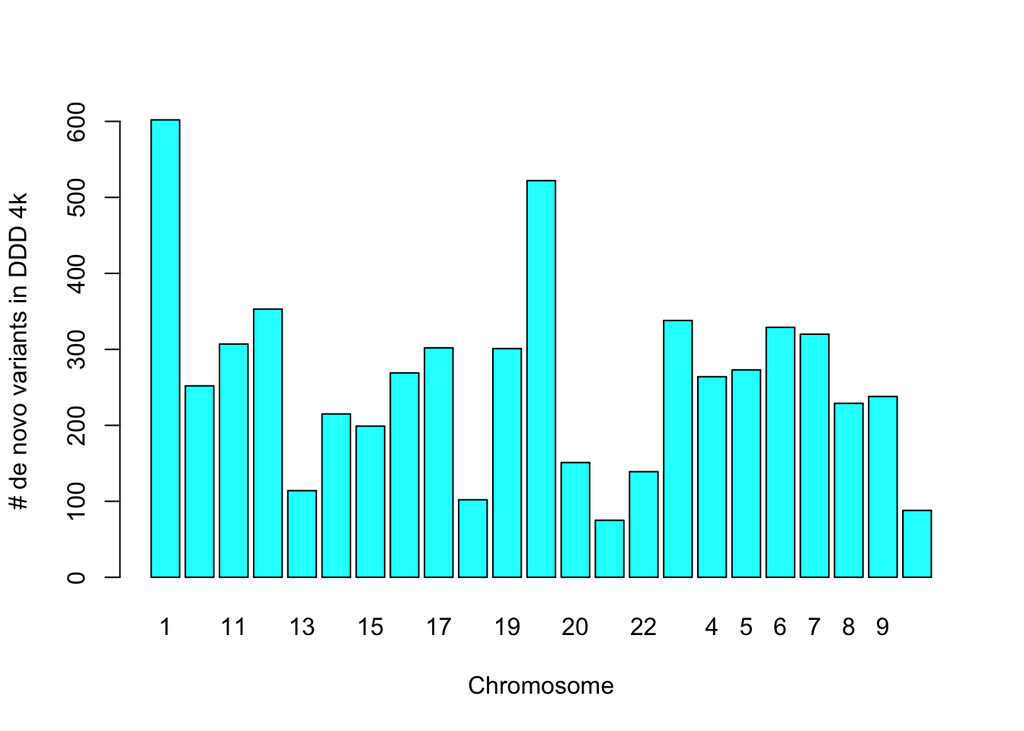

Variant ‘consequence’ given by highest VEP score:

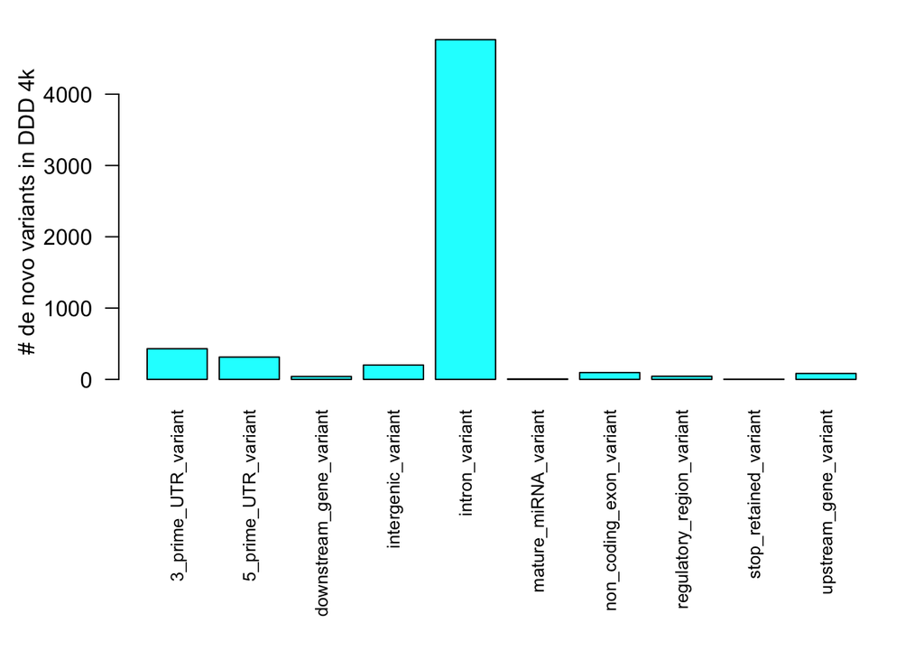

Removing intronic variants for now (unlikely to be regulatory regions), but we will still match them against regulatory regions in the v3/v5 data.

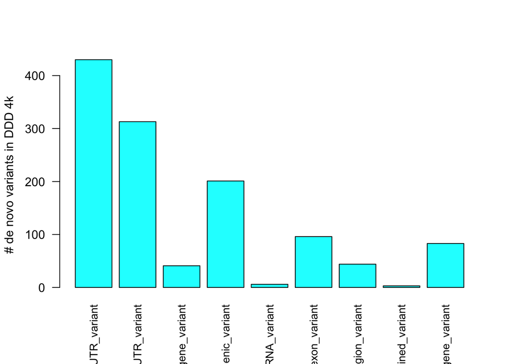

At this point we have all of the relevant data (most notably, the genomic location) for the *de novo* regulatory mutations and need to load look-up table for mutation rate. We will construct this table from the data file as a vector.

```r
mut_rates <- read.table("forSanger_1KG_mutation_rate_table.txt", header=TRUE)

p_single <- function(from, to){
  p = mut_rates$mu_snp[c(mut_rates$from == from) & c(mut_rates$to == to)]
  return(p)
}

p_all <- function(from){
  p = mut_rates$mu_snp[c(mut_rates$from == from)]
  return(sum(p))
}
```

We can use the functions `p_single(from, to)` to find the probability under the null model of mutation from a certain trinucleotide to another trinucleotide (changing the middle base). Likewise `p_all(from)` gives the probability of mutation from one trinucleotide to all three other possibilities.

Given a stretch of sequence, we want to scan across with `p_all`, adding the (assumed independent) poisson lambda terms together to arrive at a total probability distribution for mutation anywhere along the stretch of sequence. The function `p_sequence` returns this probability.

```r
# may be able to do this better with rollapply, but looping for now
p_sequence <- function(sequence){
  p = 0
  for (i in 1:nchar(sequence)){
    p = p + p_all(substr(sequence, i, i+2))  }
  return(p)
  }
```

Given a sequence, we calculate the expected number of *de novo* mutations and compare this to the observed number of *de novo* mutations. Test for support or rejection of the null hypothesis uses the poisson exact test.

```r
test_null <- function(sequence, n_denovo){
  # we are using a two sided poisson exact test
  # n_denovo is number of denovo mutations in sequence
  p_seq = p_sequence(sequence) # this is the poisson rate parameter we test against
  pt = poisson.test(n_denovo, r=p_seq, alternative="two.sided")

  # return p.value from dataframe pt - may be useful to return conf.int as well later
  return(pt$p.value)
}
```

We can use do simple example with a hypothetical regulatory sequence and obvserved number of denovo mutations shown below.

```r
seq = "CGTATACGA"
n_denovo = 2
```

W we would find a p-value of 8.487870710^{-14} using the expression `test_null(seq, n_denovo)`.